# ESC403 - Regression Anayses of the Relationship between Public Sentiment and Government Mitigation Measures during the ongoing COVID19 pandemic

Alessandro De Luca - Jessy J. Duran Ramirez - Michael Süter

## Questions and Predictions

- Q1: Is there any relationship between the mitigation measures and the sentiments from the tweets?
- Q2: Does the relationship of sentiments and mitigation category differ between the 4 countries?
- Q3: Are the two months April and August comparable?
- P1: We think that there should be no influence of the general public’s sentiment on the governmental mitigation measures
- P2: We don’t think that there should be a difference between the 4 analysed countries
- P3: We don’t think there would be differences between the two months

## Data Importing and Libraries

```r
rm(list = ls())

library(tidyverse)
library(nnet)
library(ggfortify)
library(gridExtra)
library(stargazer)
library(knitr)

## load the data ####
cases <- read.csv("../datasets/measurementrs_Covid_all_Countries&dates.csv")
sentiment <- read.csv("../datasets/tweets_sentiment_scores_method.csv")
mitigation <- read.csv("../datasets/filtered_Mitigation_gov1.csv")
```

## Data Cleaning (Preliminary)

```r
# cases #
glimpse(cases)
cases$Date <- as.Date(cases$Date, format = "%Y-%m-%d")

anyNA(cases)
which(is.na(cases$Recovered) | is.na(cases$Deaths) | is.na(cases$Confirmed))
cases[which(is.na(cases$Recovered) | is.na(cases$Deaths)), ]
## results from beginning of the pandemic measuring
## -> not important for the time period we are analysing

# change the var names
names(cases) <- c(
    "ID", "country", "province", "confirmed",
    "recovered", "deaths", "date"
)

# coding locations
cases$location_code <- with(
    cases,
    ifelse(country == "United Kingdom", "UK",
        ifelse(country == "Germany", "DE",
            ifelse(country == "Italy", "IT",
                "CH"
            )
        )
    )
)
cases$location_code <- as.factor(cases$location_code)

# sum together the province cases
cases <- cases %>%
    select(-province) %>%
    group_by(location_code, date) %>%
    summarise(
        confirmed = sum(confirmed),
        recovered = sum(recovered),
        deaths = sum(deaths)
    ) %>%
    ungroup()


# sentiment #
glimpse(sentiment)
sentiment$date <- as.Date(sentiment$date, format = "%Y-%m-%d")
sentiment$user_location <- as.factor(sentiment$user_location)
names(sentiment)[1] <- "ID"
anyNA(sentiment)
# filter for only NRC method
sentiment <- filter(sentiment, method == "NRC")

# mitigation #
glimpse(mitigation)
names(mitigation) <- tolower(names(mitigation))
names(mitigation)[1] <- "ID"
mitigation$date_implemented <- as.Date(mitigation$date_implemented,
    format = "%d-%m-%Y"
)
mitigation$entry_date <- as.Date(mitigation$entry_date,
    format = "%d-%m-%Y"
)

# coding locations
mitigation$location_code <- with(
    mitigation,
    ifelse(country == "United Kingdom", "UK",
        ifelse(country == "Germany", "DE",
            ifelse(country == "Italy", "IT",
                "CH"
            )
        )
    )
)
mitigation$location_code <- as.factor(mitigation$location_code)

anyNA(mitigation)
colnames(mitigation)[apply(mitigation, 2, anyNA)]

any(mitigation$date_implemented > mitigation$entry_date)
mitigation[
    which(mitigation$date_implemented > mitigation$entry_date),
    c("date_implemented", "entry_date")
] # I think this is due to errors in the entry_date insertion or
# inaccuracies from the source for the date_implemented

# substitute NA date_implemented w/ entry_date
mitigation <- mitigation %>%
    mutate(date_implemented = as.Date(
        ifelse(is.na(date_implemented), entry_date, date_implemented),
        origin = "1970-01-01"
    ))

# create categories based on category and introduction/phase-out
mitigation <- mitigation %>%
    mutate(category_log = ifelse(
        log_type == "Introduction / extension of measures",
        paste("INTRO -", category),
        paste("END -", category)
    ))
mitigation$category_log <- as.factor(mitigation$category_log)
mitigation$category_log <- relevel(mitigation$category_log,
    ref = "INTRO - Social distancing"
) # reference level

# filter for April and August
max(mitigation$date_implemented) # unfortunately no data for August
mitigation <- filter(
    mitigation,
    between(mitigation$date, as.Date("2020-03-29"), as.Date("2020-05-01"))
)
```

#### Cleaned data:

```r
glimpse(cases)
```

```
## Rows: 1,322
## Columns: 5
## $ location_code <fct> CH, CH, CH, CH, CH, CH, CH, CH, CH, CH, CH, CH, CH, CH, CH, CH, CH, CH, CH, CH, CH, CH, CH, CH, CH, CH, CH, CH, CH, CH, CH, CH, CH, CH, CH, CH, CH, CH, CH, CH, CH, CH, CH, CH, CH, CH, CH, CH, CH, CH, C...
## $ date          <date> 2020-02-25, 2020-02-26, 2020-02-27, 2020-02-28, 2020-02-29, 2020-03-01, 2020-03-02, 2020-03-03, 2020-03-04, 2020-03-05, 2020-03-06, 2020-03-07, 2020-03-08, 2020-03-09, 2020-03-10, 2020-03-11, 2020-03-...
## $ confirmed     <int> 1, 1, 8, 8, 18, 27, 42, 56, 90, 114, 214, 268, 337, 374, 491, 652, 815, 1139, 1359, 2200, 2200, 2700, 3028, 4075, 5294, 6575, 7474, 8795, 9877, 10897, 11811, 12928, 14076, 14829, 15922, 16605, 17768, 1...
## $ recovered     <int> 0, 0, 0, 0, 0, 0, 0, 2, 3, 3, 3, 3, 3, 3, 3, 4, 4, 4, 4, 4, 4, 4, 15, 15, 15, 15, 131, 131, 131, 131, 131, 1530, 1530, 1595, 1823, 1823, 2967, 4013, 4846, 6415, 6415, 8056, 8704, 9800, 10600, 11100, 12...
## $ deaths        <int> 0, 0, 0, 0, 0, 0, 0, 0, 0, 1, 1, 1, 2, 2, 3, 4, 4, 11, 13, 14, 14, 27, 28, 41, 54, 75, 98, 120, 122, 153, 191, 231, 264, 300, 359, 433, 488, 536, 591, 666, 715, 765, 821, 895, 948, 1002, 1036, 1106, 11...
```

```r
glimpse(sentiment)
```

```
## Rows: 117,352
## Columns: 7
## $ ID            <int> 100935, 100937, 100938, 100940, 100942, 100943, 100945, 100946, 100947, 100948, 100949, 100951, 100952, 100954, 100956, 100958, 100959, 100960, 100962, 100963, 100964, 100966, 100968, 100970, 100971, 1...
## $ date          <date> 2020-03-29, 2020-03-29, 2020-03-29, 2020-03-29, 2020-03-29, 2020-03-29, 2020-03-29, 2020-03-29, 2020-03-29, 2020-03-29, 2020-03-29, 2020-03-29, 2020-03-29, 2020-03-29, 2020-03-29, 2020-03-29, 2020-03-...
## $ user_location <fct> CH, CH, CH, CH, CH, CH, CH, CH, CH, CH, CH, CH, CH, CH, CH, CH, CH, CH, CH, CH, CH, CH, CH, CH, CH, CH, CH, CH, CH, CH, CH, CH, CH, CH, CH, CH, CH, CH, CH, CH, CH, CH, CH, CH, CH, CH, CH, CH, CH, CH, C...
## $ user_name     <chr> "CayuelaRafael", "Collider_Scope", "Collider_Scope", "DalaquaMD", "david_a_butler", "DDemin", "dgsliya", "dgsliya", "dgsliya", "FilippoGrandi", "FilippoGrandi", "FilippoGrandi", "FilippoGrandi", "gurle...
## $ index         <int> 1, 1, 1, 1, 1, 1, 1, 1, 1, 1, 1, 1, 1, 1, 1, 1, 1, 1, 1, 1, 1, 1, 1, 1, 1, 1, 1, 1, 1, 1, 1, 1, 1, 1, 1, 1, 1, 1, 1, 1, 1, 1, 1, 1, 1, 1, 1, 1, 1, 1, 1, 1, 1, 1, 1, 1, 1, 1, 1, 1, 1, 1, 1, 1, 1, 1, 1, ...
## $ method        <chr> "NRC", "NRC", "NRC", "NRC", "NRC", "NRC", "NRC", "NRC", "NRC", "NRC", "NRC", "NRC", "NRC", "NRC", "NRC", "NRC", "NRC", "NRC", "NRC", "NRC", "NRC", "NRC", "NRC", "NRC", "NRC", "NRC", "NRC", "NRC", "NRC"...
## $ net_sentiment <int> -1, -1, 1, -1, 1, 1, -1, 1, 1, 1, 1, 1, -1, 1, 1, -1, -1, 1, 1, 1, 1, -1, -1, 1, 1, 1, -1, 1, -1, 1, 1, 1, 1, 1, 0, 1, -1, 1, 1, -1, 2, -1, -1, 1, 1, 1, 1, 1, -1, 1, 1, 1, 1, 1, 1, 1, 1, 1, -1, 1, 1, 1...
```

```r
glimpse(mitigation)
```

```
## Rows: 216
## Columns: 10
## $ ID                 <int> 101, 103, 120, 121, 122, 125, 126, 128, 129, 130, 131, 132, 133, 134, 135, 136, 137, 140, 141, 142, 143, 144, 145, 146, 147, 148, 149, 150, 151, 152, 153, 154, 155, 156, 158, 159, 160, 161, 162, 1...
## $ country            <chr> "Germany", "Germany", "Switzerland", "Switzerland", "Switzerland", "Switzerland", "Switzerland", "Germany", "Germany", "Germany", "Germany", "Germany", "Germany", "Italy", "Italy", "Italy", "Italy...
## $ iso                <chr> "DEU", "DEU", "CHE", "CHE", "CHE", "CHE", "CHE", "DEU", "DEU", "DEU", "DEU", "DEU", "DEU", "ITA", "ITA", "ITA", "ITA", "ITA", "CHE", "CHE", "CHE", "CHE", "CHE", "CHE", "CHE", "DEU", "DEU", "DEU", ...
## $ log_type           <chr> "Introduction / extension of measures", "Introduction / extension of measures", "Introduction / extension of measures", "Introduction / extension of measures", "Introduction / extension of measure...
## $ category           <chr> "Public health measures", "Public health measures", "Governance and socio-economic measures", "Governance and socio-economic measures", "Governance and socio-economic measures", "Public health mea...
## $ targeted_pop_group <chr> "No", "No", "No", "No", "No", "No", "No", "No", "Yes", "Yes", "No", "No", "No", "No", "No", "No", "No", "Yes", "No", "No", "Yes", "No", "No", "Yes", "No", "Yes", "No", "Yes", "Yes", "Yes", "Yes", ...
## $ date_implemented   <date> 2020-03-30, 2020-03-30, 2020-04-03, 2020-03-31, 2020-03-31, 2020-04-03, 2020-04-03, 2020-04-03, 2020-04-01, 2020-04-03, 2020-04-03, 2020-04-02, 2020-04-05, 2020-04-03, 2020-03-31, 2020-04-01, 202...
## $ entry_date         <date> 2020-03-30, 2020-03-30, 2020-04-03, 2020-04-03, 2020-04-03, 2020-04-03, 2020-04-03, 2020-04-05, 2020-04-05, 2020-04-05, 2020-04-05, 2020-04-05, 2020-04-05, 2020-04-05, 2020-04-05, 2020-04-05, 202...
## $ location_code      <fct> DE, DE, CH, CH, CH, CH, CH, DE, DE, DE, DE, DE, DE, IT, IT, IT, IT, IT, CH, CH, CH, CH, CH, CH, CH, DE, DE, DE, DE, DE, DE, DE, IT, IT, IT, IT, IT, IT, IT, IT, IT, IT, IT, IT, IT, IT, IT, CH, CH, ...
## $ category_log       <fct> INTRO - Public health measures, INTRO - Public health measures, INTRO - Governance and socio-economic measures, INTRO - Governance and socio-economic measures, INTRO - Governance and socio-economi...
```

We have to point out here that to answer Q3 we will not be able to use a similar model to those of Q1 and Q2, because of the lack of data for the mitigation measures during the month of August.  
Unfortunately using a different month as reference is not possible due to the fact that data from Twitter is available only for the months of April and Augst.

## EDA

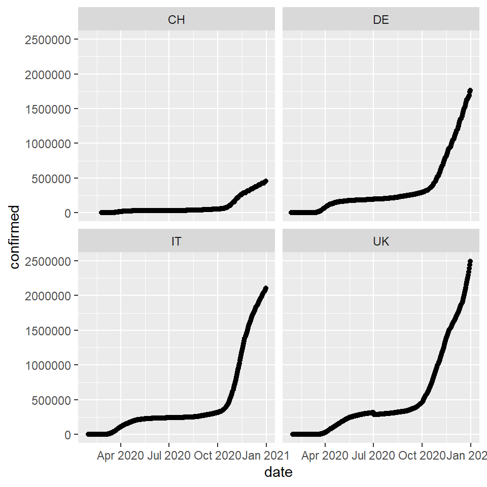

```r
# confirmed cases by country
ggplot(data = cases, aes(x = date, y = confirmed)) +
    geom_point() +
    facet_wrap(~location_code)
```

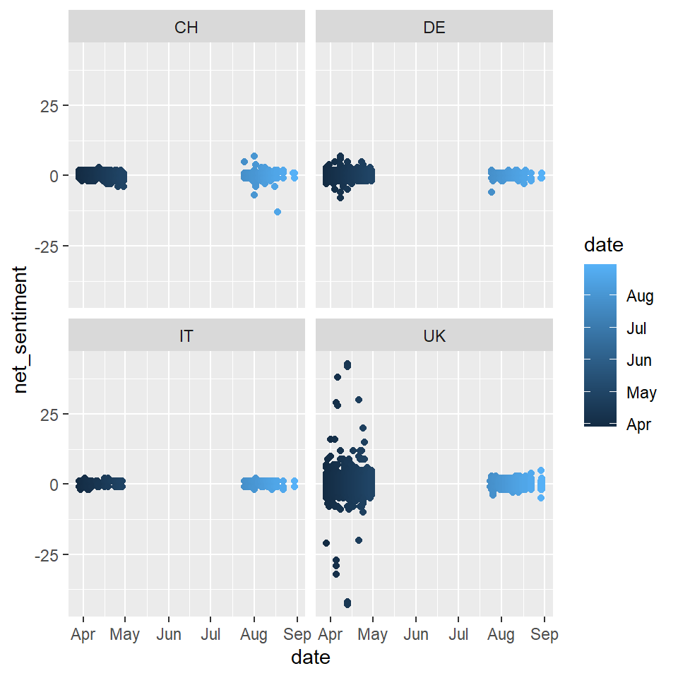

```r
# sentiment by country
ggplot(data = sentiment, aes(x = date, y = net_sentiment, colour = date)) +
    geom_point() +
    facet_wrap(~user_location)
```

```r
# mitigation measures counts by country
table(mitigation$category_log, mitigation$location_code)
```

```
##
##                                                  CH DE IT UK
##   INTRO - Social distancing                       9  3  3  0
##   END - Governance and socio-economic measures    4  0  0  0
##   END - Lockdown                                  0  0  1  0
##   END - Movement restrictions                     1  1  1  0
##   END - Public health measures                    4  1  1  0
##   END - Social distancing                         9  3  2  0
##   INTRO - Governance and socio-economic measures 37 29  9  1
##   INTRO - Lockdown                                0  1  1  1
##   INTRO - Movement restrictions                   2  5  5  0
##   INTRO - Public health measures                 23 30 29  0
```

#### Preparation for analysis

For the analyses to answer Q1 & Q2:

```r
# get a weekly mean before each measure for Q1 & Q2
df_ana_1 <- data.frame()
for (i in seq_len(nrow(mitigation))) {
    mit_row <- mitigation[i, ]

    start_date <- mit_row$date_implemented - 7
    end_date <- mit_row$date_implemented
    temp_cases <- cases %>%
        filter(
            location_code == mit_row$location_code,
            between(date, start_date, end_date)
        ) %>%
        summarise(
            confirmed_mean = mean(confirmed),
            deaths_mean = mean(deaths),
            recovered_mean = mean(recovered)
        )

    temp_sentiment <- sentiment %>%
        filter(
            user_location == mit_row$location_code,
            between(date, start_date, end_date)
        ) %>%
        summarise(sentiment_mean = mean(net_sentiment))

    temp_df <- cbind(mit_row, temp_cases, temp_sentiment)
    temp_df <- temp_df %>%
        select(
            location_code, date_implemented, category_log,
            confirmed_mean, deaths_mean, recovered_mean, sentiment_mean
        )

    df_ana_1 <- rbind(df_ana_1, temp_df)
}
```

```r
glimpse(df_ana_1)
```

```
## Rows: 216
## Columns: 7
## $ location_code    <fct> DE, DE, CH, CH, CH, CH, CH, DE, DE, DE, DE, DE, DE, IT, IT, IT, IT, IT, CH, CH, CH, CH, CH, CH, CH, DE, DE, DE, DE, DE, DE, DE, IT, IT, IT, IT, IT, IT, IT, IT, IT, IT, IT, IT, IT, IT, IT, CH, CH, CH...
## $ date_implemented <date> 2020-03-30, 2020-03-30, 2020-04-03, 2020-03-31, 2020-03-31, 2020-04-03, 2020-04-03, 2020-04-03, 2020-04-01, 2020-04-03, 2020-04-03, 2020-04-02, 2020-04-05, 2020-04-03, 2020-03-31, 2020-04-01, 2020-...
## $ category_log     <fct> INTRO - Public health measures, INTRO - Public health measures, INTRO - Governance and socio-economic measures, INTRO - Governance and socio-economic measures, INTRO - Governance and socio-economic ...
## $ confirmed_mean   <dbl> 47606.12, 47606.12, 16320.12, 13368.12, 13368.12, 16320.12, 16320.12, 70397.38, 58560.88, 70397.38, 70397.38, 64494.75, 81353.50, 103729.12, 88542.62, 93717.38, 88542.62, 121643.50, 20624.50, 20624....
## $ deaths_mean      <dbl> 338.250, 338.250, 400.250, 256.625, 256.625, 400.250, 400.250, 753.750, 515.125, 753.750, 753.750, 627.750, 1035.375, 11963.250, 9561.625, 10353.500, 9561.625, 14884.750, 684.625, 684.625, 742.125, ...
## $ recovered_mean   <dbl> 6345.750, 6345.750, 2515.875, 1086.750, 1086.750, 2515.875, 2515.875, 14958.125, 10233.750, 14958.125, 14958.125, 12595.375, 19953.250, 15199.500, 11845.250, 12910.375, 11845.250, 20081.500, 6402.00...
## $ sentiment_mean   <dbl> 0.18253968, 0.18253968, 0.32602740, 0.38947368, 0.38947368, 0.32602740, 0.32602740, 0.20533333, 0.22762646, 0.20533333, 0.20533333, 0.20095694, 0.23704415, 0.18032787, -0.02439024, 0.10204082, -0.02...
```

```r
# look for correlation between covariates
cor(df_ana_1[, 4:7]) # normal correlation only between covid measures
```

```
##                confirmed_mean deaths_mean recovered_mean sentiment_mean
## confirmed_mean      1.0000000   0.7440553     0.73096587    -0.01140660
## deaths_mean         0.7440553   1.0000000     0.18978325     0.27938798
## recovered_mean      0.7309659   0.1897833     1.00000000    -0.07884256
## sentiment_mean     -0.0114066   0.2793880    -0.07884256     1.00000000
```

For the analysis to answer Q3:

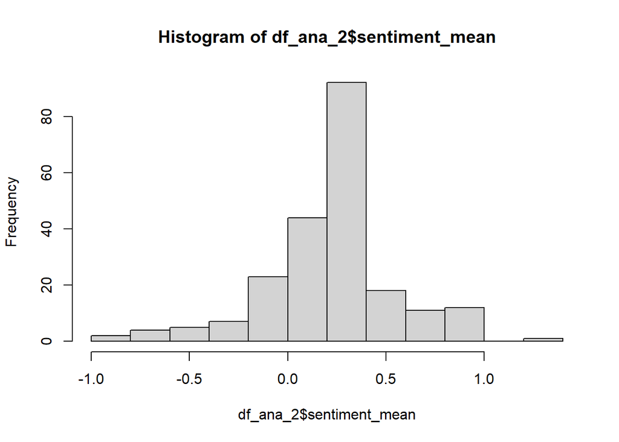

```r
# gather the data for Q3
temp_sentiment <- sentiment %>%
    group_by(user_location, date) %>%
    summarise(sentiment_mean = mean(net_sentiment)) %>%
    ungroup()
head(temp_sentiment)

df_ana_2 <- inner_join(
    x = cases, y = temp_sentiment,
    by = c("date" = "date", "location_code" = "user_location")
)

# month category
df_ana_2 <- df_ana_2 %>%
    mutate(month = ifelse(
        between(date, as.Date("2020-03-20"), as.Date("2020-05-10")),
        "April", "August"
    ))
df_ana_2$month <- as.factor(df_ana_2$month)

# polarity category (only for the multinomial regression)
summary(df_ana_2$sentiment_mean)
hist(df_ana_2$sentiment_mean)
```

```r
df_ana_2 <- df_ana_2 %>%
    mutate(sentiment_polarity = ifelse(
        sentiment_mean < -0.33, "NEG",
        ifelse(sentiment_mean > 0.33, "POS", "NEU")
    ))
df_ana_2$sentiment_polarity <- as.factor(df_ana_2$sentiment_polarity)
```

```r
glimpse(df_ana_2)
```

```
## Rows: 219
## Columns: 8
## $ location_code      <fct> CH, CH, CH, CH, CH, CH, CH, CH, CH, CH, CH, CH, CH, CH, CH, CH, CH, CH, CH, CH, CH, CH, CH, CH, CH, CH, CH, CH, CH, CH, CH, CH, CH, CH, CH, CH, CH, CH, CH, CH, CH, CH, CH, CH, CH, CH, CH, CH, CH, ...
## $ date               <date> 2020-03-29, 2020-03-30, 2020-03-31, 2020-04-01, 2020-04-02, 2020-04-03, 2020-04-04, 2020-04-05, 2020-04-06, 2020-04-07, 2020-04-08, 2020-04-09, 2020-04-10, 2020-04-11, 2020-04-12, 2020-04-13, 202...
## $ confirmed          <int> 14829, 15922, 16605, 17768, 18827, 19606, 20505, 21100, 21657, 22253, 23280, 24051, 24551, 25107, 25415, 25688, 25936, 26336, 26732, 27078, 27404, 27740, 27944, 28063, 28268, 28496, 28677, 28894, ...
## $ recovered          <int> 1595, 1823, 1823, 2967, 4013, 4846, 6415, 6415, 8056, 8704, 9800, 10600, 11100, 12100, 12700, 13700, 13700, 15400, 15900, 16400, 17100, 17800, 18600, 19400, 19900, 20600, 21000, 21300, 21800, 2220...
## $ deaths             <int> 300, 359, 433, 488, 536, 591, 666, 715, 765, 821, 895, 948, 1002, 1036, 1106, 1138, 1174, 1239, 1281, 1327, 1368, 1393, 1429, 1478, 1509, 1549, 1589, 1599, 1610, 1665, 1699, 1716, 1737, 1977, 1977...
## $ sentiment_mean     <dbl> 0.45161290, 0.39062500, 0.32812500, 0.34146341, 0.16666667, 0.29411765, 0.28723404, 0.26315789, 0.22222222, 0.33333333, 0.31746032, 0.30000000, 0.43859649, 0.29629630, 0.57142857, 0.55555556, 0.24...
## $ month              <fct> April, April, April, April, April, April, April, April, April, April, April, April, April, April, April, April, April, April, April, April, April, April, April, April, April, April, April, April, ...
## $ sentiment_polarity <fct> POS, POS, NEU, POS, NEU, NEU, NEU, NEU, NEU, POS, NEU, NEU, POS, NEU, POS, POS, NEU, NEU, POS, POS, POS, NEU, NEU, NEU, POS, POS, NEU, POS, NEU, NEU, POS, NEU, NEU, NEU, NEU, NEU, NEU, NEU, POS, N...
```

#### Looking at the relationships for the models:

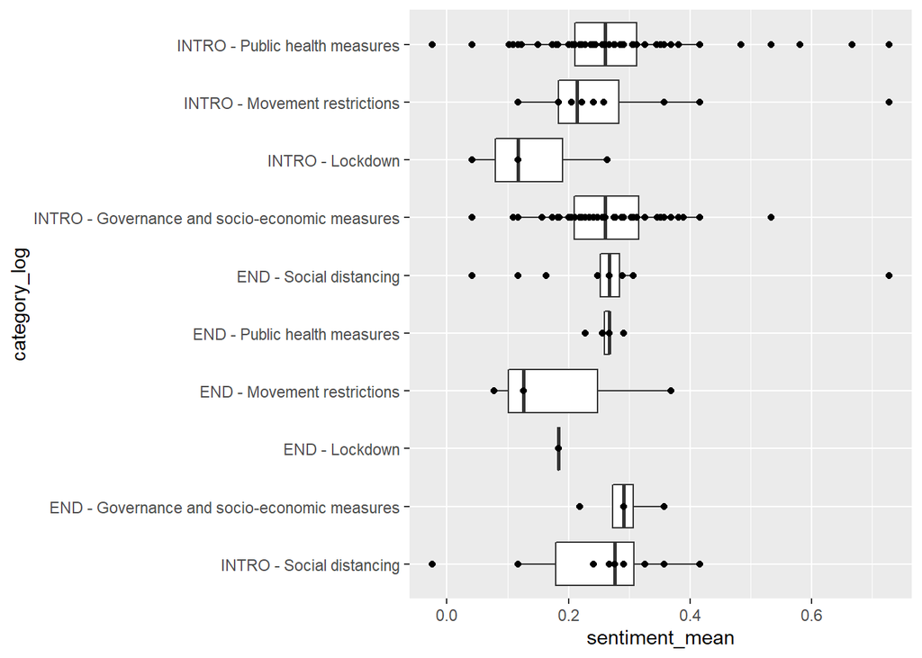

```r
# Q1
ggplot(data = df_ana_1, aes(x = sentiment_mean, y = category_log)) +
    geom_boxplot() +
    geom_point()
```

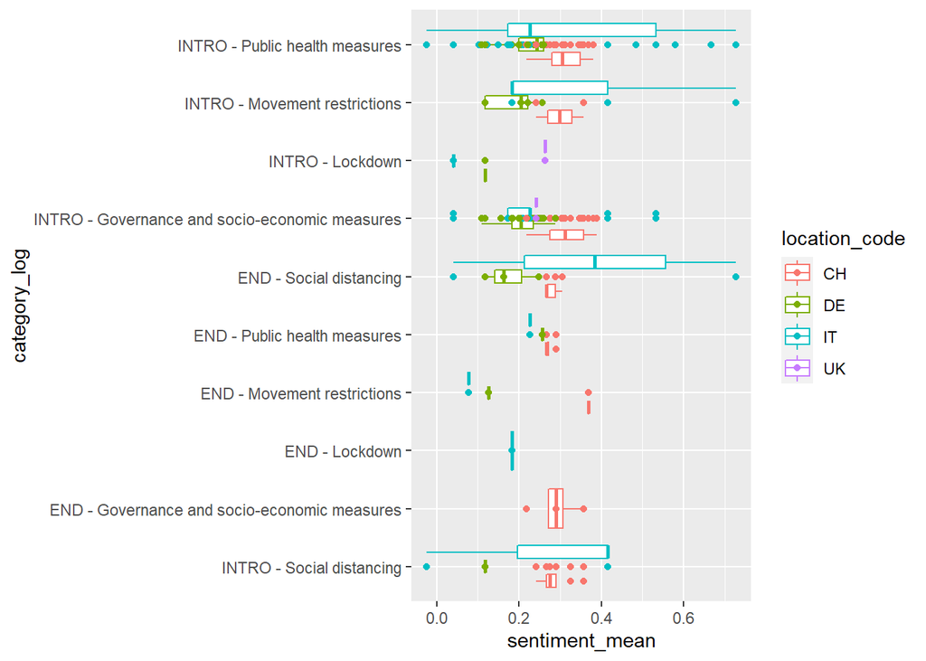

```r
# Q2
plt1 <- ggplot(data = df_ana_1, aes(
    x = sentiment_mean, y = category_log, color = location_code
)) +
    geom_boxplot() +
    geom_point()
plt2 <- ggplot(data = df_ana_1, aes(
    x = confirmed_mean, y = category_log, color = location_code
)) +
    geom_boxplot() +
    geom_point() +
    ylab("") # there is some sort of interaction
plt1 # Q2: sentiment and category interaction w/ country
```

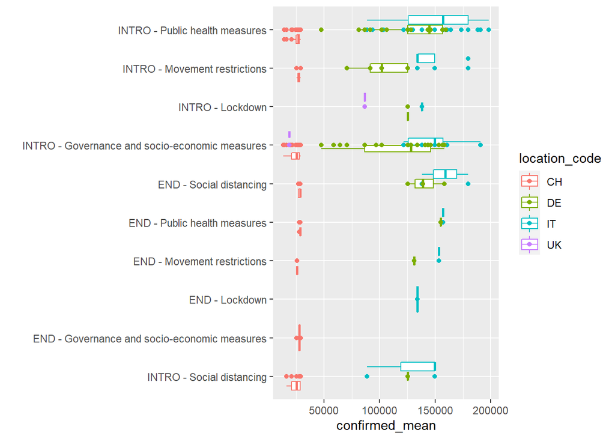

```r
plt2 # Q2: confirmed cases and category interaction w/ country
```

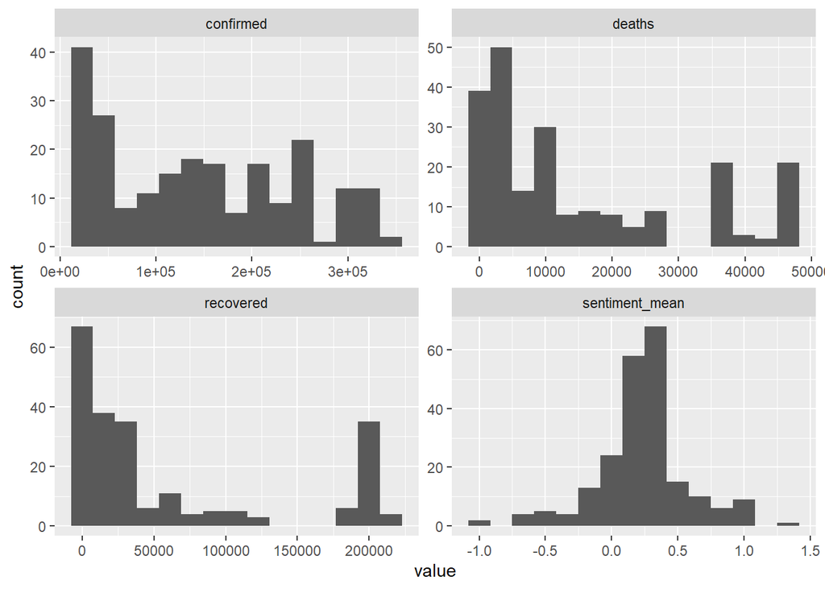

```r
# Q3
## variable exploration
ggplot(
    data = gather(df_ana_2[, 3:6], key = "variable", value = "value"),
    aes(x = value)
) +
    geom_histogram(bins = 15) +
    facet_wrap(~variable, scales = "free") ## slightly bimodal?
```

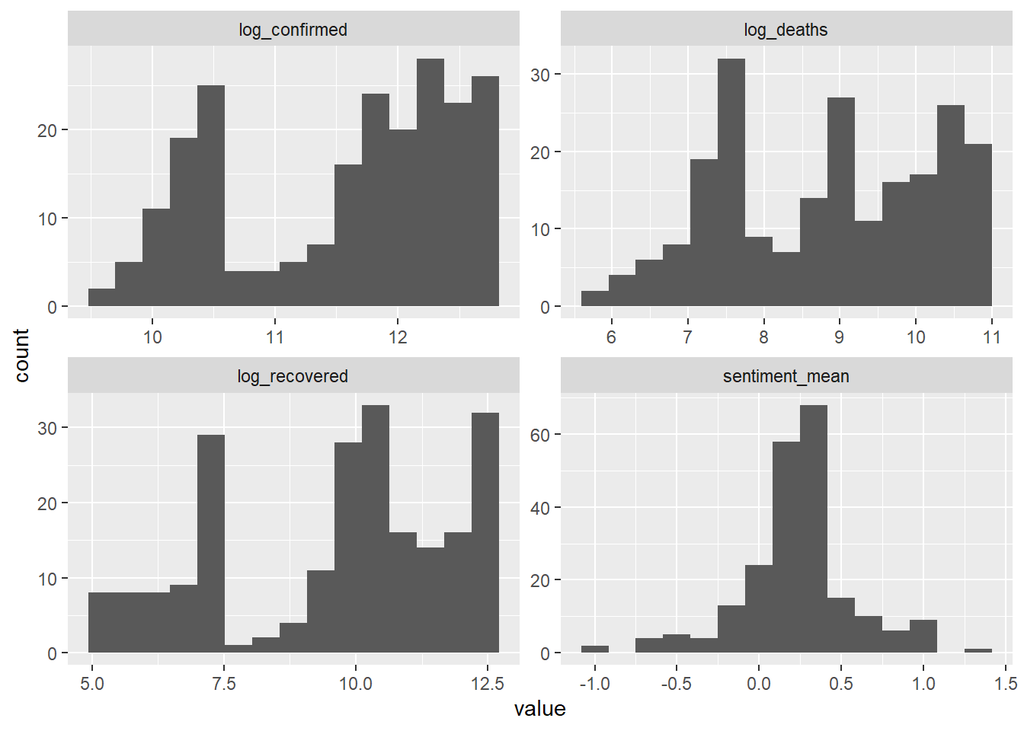

```r
## log transform
df_ana_2 <- df_ana_2 %>%
    group_by(month) %>%
    mutate(
        log_confirmed = log(confirmed),
        log_deaths = log(deaths),
        log_recovered = log(recovered)
    )
ggplot(
    data = gather(df_ana_2[, c(6, 9:11)], key = "variable", value = "value"),
    aes(x = value)
) +
    geom_histogram(bins = 15) +
    facet_wrap(~variable, scales = "free") ## better
```

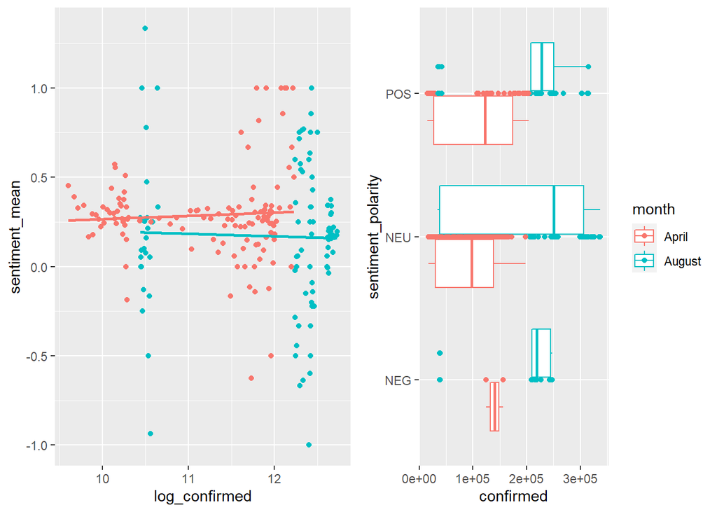

```r
## relationships (lm and multinomial models)
# linear
plt1 <- ggplot(data = df_ana_2, aes(
    x = log_confirmed, y = sentiment_mean, color = month
)) +
    geom_point() +
    geom_smooth(method = "lm", se = FALSE) + # maybe slight interaction
    theme(legend.position = "none")
# multinomial
plt2 <- ggplot(data = df_ana_2, aes(
    x = confirmed, y = sentiment_polarity, color = month
)) +
    geom_boxplot() +
    geom_point() # maybe some interaction
grid.arrange(plt1, plt2, ncol = 2)
```

## Q1: Is there any relationship between the mitigation measures and the sentiments from the tweets?

### P1: We think that there should be no influence of the general public’s sentiment on the governmental mitigation measures

#### Model:

$$\log\left(\frac{P(category\_log = Y_k)}{P(category\_log = Y_{INTRO-Social Distancing})}\right)= \beta_{k0} + \beta_{k1}(confirmed\_mean) + \beta_{k2}(recovered\_mean) + \beta_{k3}(deaths\_mean) + \beta_{k4}(sentiment\_mean)$$
With $k=$ number of levels of `category_log` (i.e. number of mitigation categories) $-1$.

```r
multi_mod <- multinom(
    category_log ~ confirmed_mean + deaths_mean
        + recovered_mean + sentiment_mean,
    data = df_ana_1
)
```

#### Summary table and Coefficients on the odds scale:

```r
s1 <- summary(multi_mod)
stargazer(multi_mod, type = "html")
```

|  | *Dependent variable:* |  |  |  |  |  |  |  |  |
| --- | --- | --- | --- | --- | --- | --- | --- | --- | --- |
|  | END - Governance and socio-economic measures | END - Lockdown | END - Movement restrictions | END - Public health measures | END - Social distancing | INTRO - Governance and socio-economic measures | INTRO - Lockdown | INTRO - Movement restrictions | INTRO - Public health measures |
|  | (1) | (2) | (3) | (4) | (5) | (6) | (7) | (8) | (9) |
| confirmed_mean | -0.0003** | 0.0002 | -0.00000 | -0.0001** | -0.00005* | 0.00001 | 0.0001*** | 0.0001*** | 0.00000 |
|  | (0.0001) | (0.0001) | (0.00003) | (0.0001) | (0.00003) | (0.00002) | (0.00003) | (0.00002) | (0.00002) |
| deaths_mean | 0.001 | -0.0003 | 0.0001 | 0.001** | 0.0003 | -0.0001 | -0.0003* | -0.0002** | 0.00004 |
|  | (0.002) | (0.001) | (0.0002) | (0.0003) | (0.0002) | (0.0001) | (0.0002) | (0.0001) | (0.0001) |
| recovered_mean | 0.0003* | -0.0003* | 0.00002 | 0.0002** | 0.0001* | -0.00000 | -0.0001* | -0.0001** | 0.00002 |
|  | (0.0002) | (0.0002) | (0.00005) | (0.0001) | (0.00004) | (0.00002) | (0.0001) | (0.00003) | (0.00002) |
| sentiment_mean | 12.623*** | -0.264*** | -3.943*** | -6.259*** | -0.306*** | 4.259*** | -5.519*** | 5.552*** | 3.470*** |
|  | (0.00000) | (0.000) | (0.000) | (0.000) | (0.000) | (0.00000) | (0.000) | (0.000) | (0.00000) |
| Constant | -3.176*** | -12.849*** | -1.561*** | 0.932*** | 0.026*** | -0.011*** | -5.240*** | -3.755*** | -0.401*** |
|  | (0.00000) | (0.00000) | (0.000) | (0.00000) | (0.000) | (0.00000) | (0.000) | (0.00000) | (0.00000) |
| Akaike Inf. Crit. | 699.651 | 699.651 | 699.651 | 699.651 | 699.651 | 699.651 | 699.651 | 699.651 | 699.651 |
| *Note:* | p<0.1; p<0.05; p<0.01 |  |  |  |  |  |  |  |  |

```r
coefs1 <- coef(multi_mod)
# coefficients on the odds-scale
kable(exp(coefs1))
```

|  | (Intercept) | confirmed_mean | deaths_mean | recovered_mean | sentiment_mean |
| --- | --- | --- | --- | --- | --- |
| END - Governance and socio-economic measures | 0.0417712 | 0.9996831 | 1.0012549 | 1.0003316 | 3.033300e+05 |
| END - Lockdown | 0.0000026 | 1.0001895 | 0.9996937 | 0.9996652 | 7.680259e-01 |
| END - Movement restrictions | 0.2098604 | 0.9999999 | 1.0000560 | 1.0000150 | 1.939080e-02 |
| END - Public health measures | 2.5383701 | 0.9998636 | 1.0007604 | 1.0001647 | 1.912400e-03 |
| END - Social distancing | 1.0258548 | 0.9999506 | 1.0002669 | 1.0000699 | 7.363462e-01 |
| INTRO - Governance and socio-economic measures | 0.9888791 | 1.0000143 | 0.9999021 | 0.9999989 | 7.075292e+01 |
| INTRO - Lockdown | 0.0053000 | 1.0001110 | 0.9996504 | 0.9998667 | 4.008500e-03 |
| INTRO - Movement restrictions | 0.0233959 | 1.0000627 | 0.9997775 | 0.9999343 | 2.578369e+02 |
| INTRO - Public health measures | 0.6693626 | 1.0000047 | 1.0000372 | 1.0000172 | 3.213246e+01 |

#### Statistical test (Z-test):

```r
# statistical test (Z-test)
z <- s1$coefficients / s1$standard.error
p <- pnorm(abs(z), lower.tail = FALSE) * 2
kable(p) ## some extreme z scores => p-values = 0
```

|  | (Intercept) | confirmed_mean | deaths_mean | recovered_mean | sentiment_mean |
| --- | --- | --- | --- | --- | --- |
| END - Governance and socio-economic measures | 0 | 0.0337509 | 0.5425239 | 0.0843283 | 0 |
| END - Lockdown | 0 | 0.1450739 | 0.7661226 | 0.0677798 | 0 |
| END - Movement restrictions | 0 | 0.9975425 | 0.7892830 | 0.7618800 | 0 |
| END - Public health measures | 0 | 0.0167325 | 0.0206724 | 0.0113679 | 0 |
| END - Social distancing | 0 | 0.0729106 | 0.1117178 | 0.0516200 | 0 |
| INTRO - Governance and socio-economic measures | 0 | 0.3480316 | 0.3142175 | 0.9617909 | 0 |
| INTRO - Lockdown | 0 | 0.0012375 | 0.0640209 | 0.0641938 | 0 |
| INTRO - Movement restrictions | 0 | 0.0007431 | 0.0441358 | 0.0469844 | 0 |
| INTRO - Public health measures | 0 | 0.7664471 | 0.7057992 | 0.4755444 | 0 |

```r
# compute p-values on log-scale
p_extr <- log(2) + pnorm(abs(z), lower.tail = FALSE, log.p = TRUE)
kable(p_extr)
```

|  | (Intercept) | confirmed_mean | deaths_mean | recovered_mean | sentiment_mean |
| --- | --- | --- | --- | --- | --- |
| END - Governance and socio-economic measures | -1.502571e+13 | -3.3887481 | -0.6115231 | -2.4730379 | -1.395247e+15 |
| END - Lockdown | -1.642768e+16 | -1.9305122 | -0.2664130 | -2.6914910 | -4.174208e+16 |
| END - Movement restrictions | -1.450800e+16 | -0.0024606 | -0.2366304 | -0.2719662 | -1.131280e+19 |
| END - Public health measures | -2.413957e+14 | -4.0904023 | -3.8789555 | -4.4769640 | -1.336554e+17 |
| END - Social distancing | -2.225904e+12 | -2.6185213 | -2.1917791 | -2.9638461 | -4.443176e+14 |
| INTRO - Governance and socio-economic measures | -6.326258e+08 | -1.0554619 | -1.1576700 | -0.0389582 | -4.667508e+14 |
| INTRO - Lockdown | -8.089356e+16 | -6.6946571 | -2.7485453 | -2.7458488 | -1.421507e+18 |
| INTRO - Movement restrictions | -1.589618e+16 | -7.2046601 | -3.1204846 | -3.0579392 | -8.016691e+17 |
| INTRO - Public health measures | -3.453789e+12 | -0.2659895 | -0.3484245 | -0.7432949 | -1.689034e+15 |

#### Results Figure:

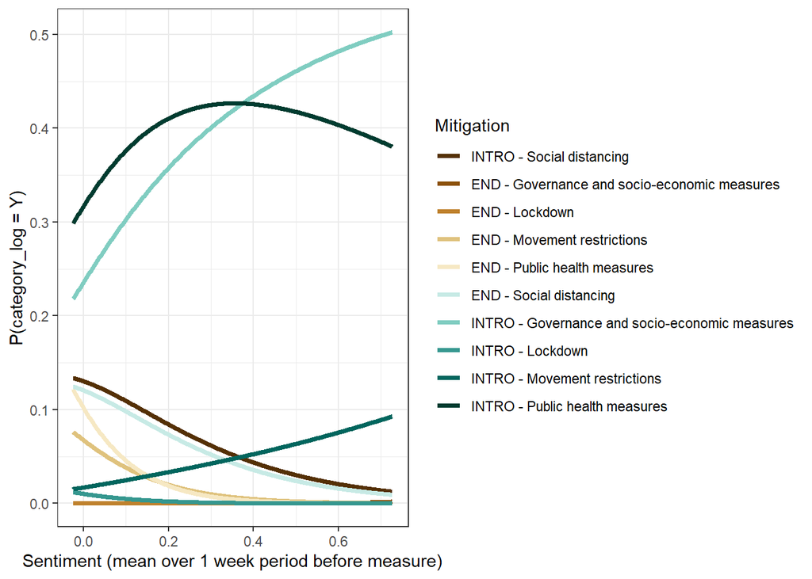

```r
newdf_1 <- data.frame(
    sentiment_mean = seq(
        from = min(df_ana_1$sentiment_mean),
        to = max(df_ana_1$sentiment_mean),
        length.out = 500
    ),
    confirmed_mean = rep(mean(df_ana_1$confirmed_mean), 500),
    deaths_mean = rep(mean(df_ana_1$deaths_mean), 500),
    recovered_mean = rep(mean(df_ana_1$recovered_mean), 500)
)
prob_1 <- predict(multi_mod, newdata = newdf_1, type = "probs", se = TRUE)
predicted_probs_1 <- cbind(newdf_1, prob_1)

# to long format
long_predicted_probs_1 <- gather(predicted_probs_1,
    key = "Mitigation",
    value = "probability",
    -sentiment_mean, -confirmed_mean, -deaths_mean, -recovered_mean,
    factor_key = TRUE
)

ggplot(
    data = long_predicted_probs_1,
    aes(x = sentiment_mean, y = probability, color = Mitigation)
) +
    geom_line(size = 1.3) +
    scale_color_brewer(type = "div") +
    xlab("Sentiment (mean over 1 week period before measure)") +
    ylab("P(category_log = Y)") +
    theme_bw()
```

#### Conclusions:

Unlike our predictions the public sentiment has a **huge effect** on the decision-making of governments on mitigation measures (measured as odds of a certain category of mitigation measures).  
Moreover, the other predictors, which are all COVID-19 measures indicating the course of the pandemic on average in the week before the implementation of a mitigation measure, have a miniscule impact on the mitigation measure taken compared to the public sentiment.  
Another important aspect is that looking at the `(Intercept)` $\beta_{k0}$ there seems to be a difference in odds for the mitigation categories w.r.t. the reference category *INTRO-Social Distancing*; an interesting insight from this is that both the introduction and ending of lockdown measures have very low odds compared to the reference category.  
The p-values of the coefficients confirm the significant difference in the odds of the different categories of mitigation measures and the significant impact the public sentiment has on these odds.  
An important aspect is that although difficult to notice by looking at the coefficients table, there is weak to very strong evidence of a relationship between COVID-19 measures and the odds of certain categories of mitigation measures.  
In conclusion, we found evidence of a strong relationship between public sentiment and the odds of a government introducing certain categories of mitigation measures.  
This is in contrast with our prediction that the public sentiment would have no influence on the odds of a government introducing certain categories of mitigation measures.  
The main drawbacks of this analysis is the uncertainty in the significance of using averaged sentiment data over a week and the fact that the sentiment analysis does not differ between opinions on COVID-19 and the management of the pandemic by a governemnt, thus possibly losing important information or misclassifying the opinion.

## Q2: Does the relationship of sentiments and mitigation category differ between the 4 countries?

### P2: We don’t think that there should be a difference between the 4 analysed countries

#### Model:

Essentially the same model as in Q1 but with added covariate `location_code`and interaction terms relative to this new predictors’ categories:
$$\log\left(\frac{P(category\_log = Y_k)}{P(category\_log = Y_{INTRO-Social Distancing})}\right)= \dotsc + \beta_{k5}location\_code_{DE} + \beta_{k6}location\_code_{IT} + \beta_{k7}location\_code_{UK} + z_{k1}(confirmed\_mean)(location\_code_{DE}) + z_{k2}(confirmed\_mean)(location\_code_{IT}) + z_{k2}(confirmed\_mean)(location\_code_{UK}) + \dotsc$$
With $k=$ number of levels of `category_log` (i.e. number of mitigation categories) $-1$.
$z_{kn}$ are the interaction coefficients: $n=12$, 3 interaction terms (num. of countries - 1) for each other covariate.

```r
multi_mod_2 <- multinom(category_log ~ (confirmed_mean + deaths_mean
    + recovered_mean + sentiment_mean) * location_code,
data = df_ana_1
)
```

#### Summary table and Coefficients on the odds scale:

```r
s2 <- summary(multi_mod_2)
stargazer(multi_mod_2, type = "html")
```

|  | *Dependent variable:* |  |  |  |  |  |  |  |  |
| --- | --- | --- | --- | --- | --- | --- | --- | --- | --- |
|  | END - Governance and socio-economic measures | END - Lockdown | END - Movement restrictions | END - Public health measures | END - Social distancing | INTRO - Governance and socio-economic measures | INTRO - Lockdown | INTRO - Movement restrictions | INTRO - Public health measures |
|  | (1) | (2) | (3) | (4) | (5) | (6) | (7) | (8) | (9) |
| confirmed_mean | 0.0004*** | -0.003*** | -0.002*** | 0.004*** | 0.002*** | -0.0004*** | -0.003*** | 0.00002 | -0.0005*** |
|  | (0.0001) | (0.0002) | (0.0001) | (0.0002) | (0.0002) | (0.0001) | (0.0002) | (0.0002) | (0.0001) |
| deaths_mean | -0.033*** | 0.195*** | 0.130*** | -0.274*** | -0.157*** | 0.027*** | 0.185*** | -0.010*** | 0.030*** |
|  | (0.003) | (0.002) | (0.003) | (0.0001) | (0.003) | (0.001) | (0.005) | (0.002) | (0.001) |
| recovered_mean | 0.002*** | -0.010*** | -0.007*** | 0.015*** | 0.009*** | -0.001*** | -0.010*** | 0.001** | -0.002*** |
|  | (0.0002) | (0.0004) | (0.0003) | (0.0002) | (0.0003) | (0.0001) | (0.0005) | (0.0003) | (0.0001) |
| sentiment_mean | 0.015*** | -0.022*** | -0.410*** | -0.492*** | -0.239*** | 0.144*** | -0.415*** | 0.848*** | 0.242*** |
|  | (0.00000) | (0.00000) | (0.00000) | (0.00000) | (0.00000) | (0.00000) | (0.00000) | (0.00000) | (0.00000) |
| location_codeDE | -0.087*** | -0.059*** | -0.069*** | -0.041*** | -0.043*** | 1.133*** | -0.097*** | -0.969*** | 0.346*** |
|  | (0.00000) | (0.00000) | (0.00000) | (0.00000) | (0.00000) | (0.00000) | (0.00000) | (0.00000) | (0.00000) |
| location_codeIT | -0.001*** | 0.037*** | -0.044*** | -0.035*** | 0.039*** | 0.021*** | 0.014*** | 0.110*** | -0.040*** |
|  | (0.00000) | (0.00000) | (0.00000) | (0.00000) | (0.00000) | (0.00000) | (0.00000) | (0.00000) | (0.00000) |
| location_codeUK | -0.00002*** | 0.0001*** | 0.0001*** | -0.0002*** | -0.0001*** | 0.00002*** | 0.0001*** | -0.00000*** | 0.00002*** |
|  | (0.00000) | (0.000) | (0.000) | (0.000) | (0.000) | (0.00000) | (0.00000) | (0.00000) | (0.00000) |
| confirmed_mean:location_codeDE | -0.0004** | 0.003*** | 0.002*** | -0.004*** | -0.002*** | 0.0004*** | 0.003*** | 0.0001 | 0.001*** |
|  | (0.0002) | (0.0002) | (0.0002) | (0.0002) | (0.0002) | (0.0001) | (0.0002) | (0.0002) | (0.0001) |
| confirmed_mean:location_codeIT | -0.001 | 0.003*** | 0.002*** | -0.005*** | -0.003*** | 0.0002 | 0.003*** | -0.0004 | 0.0005*** |
|  | (0.001) | (0.0005) | (0.001) | (0.0002) | (0.001) | (0.0002) | (0.001) | (0.001) | (0.0002) |
| confirmed_mean:location_codeUK | 0.0001 | 0.003*** | 0.002* | -0.004*** | -0.002*** | 0.001* | 0.003*** | 0.0004 | 0.001 |
|  | (0.001) | (0.001) | (0.001) | (0.001) | (0.001) | (0.001) | (0.001) | (0.001) | (0.001) |
| deaths_mean:location_codeDE | 0.051*** | -0.182*** | -0.129*** | 0.296*** | 0.162*** | -0.009*** | -0.181*** | 0.027*** | -0.008*** |
|  | (0.0001) | (0.00004) | (0.0001) | (0.00005) | (0.0003) | (0.002) | (0.001) | (0.003) | (0.002) |
| deaths_mean:location_codeIT | 0.033*** | -0.193*** | -0.127*** | 0.286*** | 0.161*** | -0.025*** | -0.180*** | 0.014*** | -0.030*** |
|  | (0.003) | (0.002) | (0.003) | (0.0001) | (0.003) | (0.002) | (0.003) | (0.003) | (0.001) |
| deaths_mean:location_codeUK | 0.028*** | -0.189*** | -0.129*** | 0.276*** | 0.158*** | -0.034*** | -0.185*** | 0.007*** | -0.034*** |
|  | (0.0001) | (0.0001) | (0.0001) | (0.0001) | (0.0001) | (0.00004) | (0.001) | (0.002) | (0.0001) |
| recovered_mean:location_codeDE | -0.003*** | 0.010*** | 0.007*** | -0.016*** | -0.009*** | 0.0005*** | 0.010*** | -0.002*** | 0.0003* |
|  | (0.0002) | (0.0004) | (0.0003) | (0.0003) | (0.0002) | (0.0002) | (0.0004) | (0.0003) | (0.0002) |
| recovered_mean:location_codeIT | -0.002*** | 0.010*** | 0.007*** | -0.016*** | -0.009*** | 0.001*** | 0.009*** | -0.001** | 0.002*** |
|  | (0.0005) | (0.0005) | (0.0005) | (0.0004) | (0.0004) | (0.0002) | (0.001) | (0.0005) | (0.0002) |
| recovered_mean:location_codeUK | -0.001*** | 0.010*** | 0.007*** | -0.015*** | -0.008*** | 0.002*** | 0.010*** | -0.0004*** | 0.002*** |
|  | (0.00001) | (0.00000) | (0.00001) | (0.00000) | (0.00000) | (0.00001) | (0.0001) | (0.0001) | (0.00001) |
| sentiment_mean:location_codeDE | -0.014*** | -0.010*** | -0.026*** | 0.012*** | -0.046*** | 0.308*** | -0.013*** | -0.150*** | -0.052*** |
|  | (0.00000) | (0.00000) | (0.00000) | (0.00000) | (0.00000) | (0.00000) | (0.00000) | (0.00000) | (0.00000) |
| sentiment_mean:location_codeIT | -0.004*** | -0.005*** | -0.533*** | -0.415*** | 0.129*** | -0.521*** | -0.395*** | 0.920*** | 0.185*** |
|  | (0.00000) | (0.00000) | (0.00000) | (0.00000) | (0.00000) | (0.00000) | (0.00000) | (0.00000) | (0.00000) |
| sentiment_mean:location_codeUK | -0.00000*** | 0.00003*** | 0.00002*** | -0.00004*** | -0.00002*** | 0.00001*** | 0.00003*** | -0.00000*** | 0.00001*** |
|  | (0.000) | (0.000) | (0.000) | (0.000) | (0.000) | (0.000) | (0.00000) | (0.00000) | (0.00000) |
| Constant | -0.117*** | -0.038*** | -0.226*** | -0.216*** | -0.464*** | 1.699*** | -0.092*** | -0.913*** | 0.265*** |
|  | (0.00000) | (0.00000) | (0.00000) | (0.00000) | (0.00000) | (0.00000) | (0.00000) | (0.00000) | (0.00000) |
| Akaike Inf. Crit. | 871.809 | 871.809 | 871.809 | 871.809 | 871.809 | 871.809 | 871.809 | 871.809 | 871.809 |
| *Note:* | p<0.1; p<0.05; p<0.01 |  |  |  |  |  |  |  |  |

Because of the large amount of model coefficients the table of the coefficients on the odds-scale contains only those of interest for the question at hand, namely the coefficients for the different levels of `location_code` and the interaction terms.

```r
coefs2 <- coef(multi_mod_2)
# only concerned w/ location_code and interaction terms
coefs2 <- coefs2[, c(1, 6:20)]
# on the odds-scale
kable(exp(coefs2))
```

|  | (Intercept) | location_codeDE | location_codeIT | location_codeUK | confirmed_mean:location_codeDE | confirmed_mean:location_codeIT | confirmed_mean:location_codeUK | deaths_mean:location_codeDE | deaths_mean:location_codeIT | deaths_mean:location_codeUK | recovered_mean:location_codeDE | recovered_mean:location_codeIT | recovered_mean:location_codeUK | sentiment_mean:location_codeDE | sentiment_mean:location_codeIT | sentiment_mean:location_codeUK |
| --- | --- | --- | --- | --- | --- | --- | --- | --- | --- | --- | --- | --- | --- | --- | --- | --- |
| END - Governance and socio-economic measures | 0.8894035 | 0.9166489 | 0.9988234 | 0.9999817 | 0.9996077 | 0.9994875 | 1.0000668 | 1.0524906 | 1.0339808 | 1.0280332 | 0.9970926 | 0.9980765 | 0.9985548 | 0.9856651 | 0.9964136 | 0.9999957 |
| END - Lockdown | 0.9629146 | 0.9428519 | 1.0376200 | 1.0001252 | 1.0033762 | 1.0031345 | 1.0026799 | 0.8337764 | 0.8248251 | 0.8278424 | 1.0095759 | 1.0100593 | 1.0099694 | 0.9904082 | 0.9947653 | 1.0000294 |
| END - Movement restrictions | 0.7977992 | 0.9337455 | 0.9568054 | 1.0000854 | 1.0022156 | 1.0018952 | 1.0020441 | 0.8790668 | 0.8804378 | 0.8790894 | 1.0068344 | 1.0066675 | 1.0067918 | 0.9746973 | 0.5870747 | 1.0000201 |
| END - Public health measures | 0.8060953 | 0.9601012 | 0.9652594 | 0.9998170 | 0.9959210 | 0.9946955 | 0.9957341 | 1.3447043 | 1.3304950 | 1.3181593 | 0.9838571 | 0.9841738 | 0.9855965 | 1.0119898 | 0.6604038 | 0.9999570 |
| END - Social distancing | 0.6289225 | 0.9575859 | 1.0399882 | 0.9998951 | 0.9976879 | 0.9972781 | 0.9975923 | 1.1761059 | 1.1745533 | 1.1715585 | 0.9910198 | 0.9910168 | 0.9917190 | 0.9547061 | 1.1375956 | 0.9999753 |
| INTRO - Governance and socio-economic measures | 5.4693740 | 3.1046889 | 1.0211606 | 1.0000225 | 1.0004410 | 1.0001628 | 1.0011465 | 0.9912861 | 0.9754496 | 0.9667168 | 1.0004947 | 1.0013309 | 1.0017867 | 1.3609793 | 0.5941063 | 1.0000053 |
| INTRO - Lockdown | 0.9117337 | 0.9075510 | 1.0136117 | 1.0001226 | 1.0032015 | 1.0027048 | 1.0033417 | 0.8344763 | 0.8353155 | 0.8311323 | 1.0095558 | 1.0092654 | 1.0097676 | 0.9869641 | 0.6737217 | 1.0000288 |
| INTRO - Movement restrictions | 0.4013732 | 0.3793351 | 1.1163314 | 0.9999955 | 1.0000723 | 0.9995694 | 1.0003851 | 1.0268680 | 1.0138889 | 1.0068707 | 0.9982816 | 0.9988853 | 0.9996462 | 0.8609191 | 2.5091060 | 0.9999989 |
| INTRO - Public health measures | 1.3037969 | 1.4133285 | 0.9611705 | 1.0000227 | 1.0005217 | 1.0004799 | 1.0007831 | 0.9924872 | 0.9702326 | 0.9663241 | 1.0003411 | 1.0016126 | 1.0018038 | 0.9494203 | 1.2030081 | 1.0000053 |

#### Statistical test (Z-test):

```r
# statistical test (Z-test)
z2 <- coefs2 / s2$standard.error[, c(1, 6:20)]
p2 <- pnorm(abs(z2), lower.tail = FALSE) * 2
kable(p2) ## again some very extreme p-values
```

|  | (Intercept) | location_codeDE | location_codeIT | location_codeUK | confirmed_mean:location_codeDE | confirmed_mean:location_codeIT | confirmed_mean:location_codeUK | deaths_mean:location_codeDE | deaths_mean:location_codeIT | deaths_mean:location_codeUK | recovered_mean:location_codeDE | recovered_mean:location_codeIT | recovered_mean:location_codeUK | sentiment_mean:location_codeDE | sentiment_mean:location_codeIT | sentiment_mean:location_codeUK |
| --- | --- | --- | --- | --- | --- | --- | --- | --- | --- | --- | --- | --- | --- | --- | --- | --- |
| END - Governance and socio-economic measures | 0 | 0 | 0 | 0.00e+00 | 0.0107897 | 0.3274555 | 0.9411472 | 0.0000000 | 0.00e+00 | 0e+00 | 0.0000000 | 0.0000757 | 0.00e+00 | 0 | 0 | 0.00e+00 |
| END - Lockdown | 0 | 0 | 0 | 0.00e+00 | 0.0000000 | 0.0000000 | 0.0000069 | 0.0000000 | 0.00e+00 | 0e+00 | 0.0000000 | 0.0000000 | 0.00e+00 | 0 | 0 | 0.00e+00 |
| END - Movement restrictions | 0 | 0 | 0 | 0.00e+00 | 0.0000000 | 0.0033877 | 0.0522892 | 0.0000000 | 0.00e+00 | 0e+00 | 0.0000000 | 0.0000000 | 0.00e+00 | 0 | 0 | 0.00e+00 |
| END - Public health measures | 0 | 0 | 0 | 0.00e+00 | 0.0000000 | 0.0000000 | 0.0000000 | 0.0000000 | 0.00e+00 | 0e+00 | 0.0000000 | 0.0000000 | 0.00e+00 | 0 | 0 | 0.00e+00 |
| END - Social distancing | 0 | 0 | 0 | 0.00e+00 | 0.0000000 | 0.0000128 | 0.0001399 | 0.0000000 | 0.00e+00 | 0e+00 | 0.0000000 | 0.0000000 | 0.00e+00 | 0 | 0 | 0.00e+00 |
| INTRO - Governance and socio-economic measures | 0 | 0 | 0 | 0.00e+00 | 0.0000000 | 0.4639808 | 0.0770984 | 0.0000366 | 0.00e+00 | 0e+00 | 0.0046702 | 0.0000001 | 0.00e+00 | 0 | 0 | 0.00e+00 |
| INTRO - Lockdown | 0 | 0 | 0 | 0.00e+00 | 0.0000000 | 0.0004914 | 0.0002923 | 0.0000000 | 0.00e+00 | 0e+00 | 0.0000000 | 0.0000000 | 0.00e+00 | 0 | 0 | 0.00e+00 |
| INTRO - Movement restrictions | 0 | 0 | 0 | 1.03e-05 | 0.6751916 | 0.3969711 | 0.5535166 | 0.0000000 | 2.44e-05 | 6e-06 | 0.0000000 | 0.0154049 | 1.43e-05 | 0 | 0 | 1.04e-05 |
| INTRO - Public health measures | 0 | 0 | 0 | 0.00e+00 | 0.0000000 | 0.0026855 | 0.5449511 | 0.0006287 | 0.00e+00 | 0e+00 | 0.0624503 | 0.0000000 | 0.00e+00 | 0 | 0 | 0.00e+00 |

#### Results Figure:

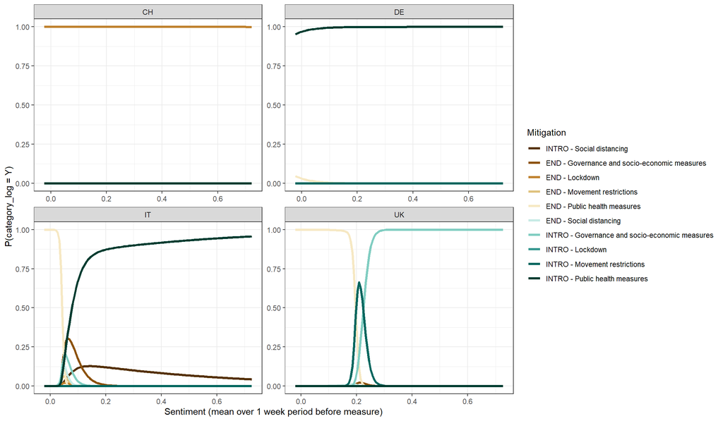

```r
newdf_2 <- data.frame(
    sentiment_mean = seq(
        from = min(df_ana_1$sentiment_mean),
        to = max(df_ana_1$sentiment_mean),
        length.out = 500
    ),
    location_code = as.factor(rep(levels(df_ana_1$location_code), 500)),
    confirmed_mean = seq(
        from = min(df_ana_1$confirmed_mean),
        to = max(df_ana_1$confirmed_mean),
        length.out = 500
    ),
    deaths_mean = rep(mean(df_ana_1$deaths_mean), 500),
    recovered_mean = rep(mean(df_ana_1$recovered_mean), 500)
)
prob_2 <- predict(multi_mod_2, newdata = newdf_2, type = "probs", se = TRUE)
predicted_probs_2 <- cbind(newdf_2, prob_2)

# to long format
long_predicted_probs_2 <- gather(predicted_probs_2,
    key = "Mitigation",
    value = "probability",
    -sentiment_mean, -confirmed_mean, -deaths_mean, -recovered_mean,
    -location_code,
    factor_key = TRUE
)

ggplot(
    data = long_predicted_probs_2,
    aes(x = sentiment_mean, y = probability, color = Mitigation)
) +
    geom_line(size = 1.3) +
    scale_color_brewer(type = "div") +
    xlab("Sentiment (mean over 1 week period before measure)") +
    ylab("P(category_log = Y)") +
    theme_bw() +
    facet_wrap(~location_code, scales = "free")
```

## Q3: Are the two months April and August comparable?

### P3: We don’t think there would be differences between the two months

#### Models:

**Linear Model:**
$$sentiment\_mean = \beta_0 + \beta_1(log(confirmed)) + \beta_2(log(recovered)) + \beta_3(log(deaths)) + \beta_4(month_{August}) + z_1(log(confirmed))(month_{August}) + z_2(log(recovered))(month_{August}) + z_3(log(deaths))(month_{August})$$
In this case `sentiment_mean` unlike the previous two models is not the mean of the public sentiment score over a 1 week period, but simply the daily sentiment mean.

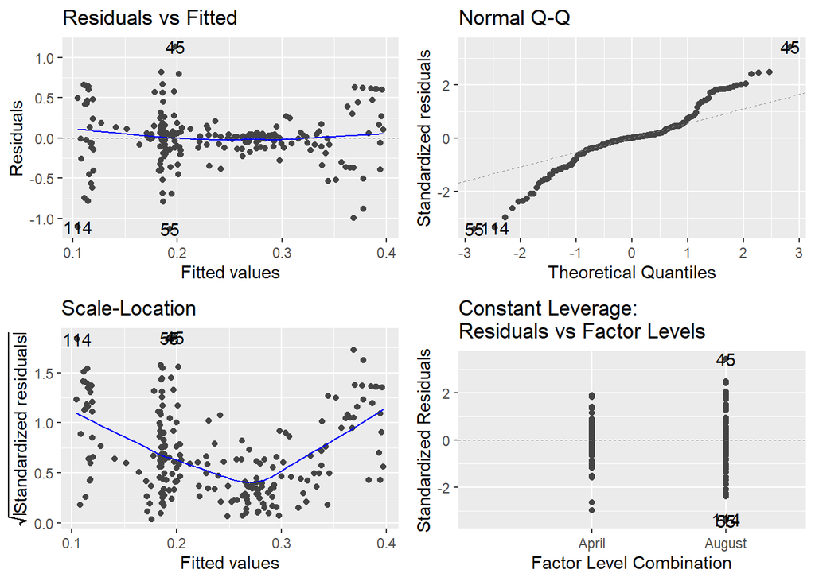

```r
lm_mod <- lm(sentiment_mean ~ (log_confirmed + log_recovered
    + log_deaths) * month,
data = df_ana_2
)

autoplot(lm_mod) # model diagnostics -> normality & homoskedasticity ?
```

There are some doubts on some of the linear model assumptions not being met (mainly normality of the residuals and homoskedasticity). The transformation of the COVID-19 measures to the log scale does not seem to help in this case and only minimizes differences between the two months. Rescaling and other transformations were excluded due to creating too skewed distributions or impossible values (e.g. negative number of deaths). Hence a categorical encoding of the sentiment scores and a multinomial regression was also applied to answer this question.

**Multinomial Model:**
$$\log\left(\frac{P(sentiment\_polarity = Y_k)}{P(sentiment\_polarity = Y_{NEG})}\right)=\beta_{k0} + \beta_{k1}(confirmed) + \beta_{k2}(recovered) + \beta_{k3}(deaths) + \beta_{k4}(month_{August}) + z_{k1}(confirmed)(month_{August}) + z_{k2}(recovered)(month_{August}) + z_{k3}(deaths)(month_{August})$$
With $k=$ number of levels of `sentiment_polarity` (i.e. NEG, NEU, POS) $-1$.

```r
multi_mod_3 <- multinom(sentiment_polarity ~
(confirmed + recovered + deaths) * month,
data = df_ana_2
)
```

#### Summary table and Coefficients:

**Linear Model:**

```r
stargazer(lm_mod, type = "html")
```

|  | *Dependent variable:* |
| --- | --- |
|  | sentiment_mean |
| log_confirmed | -0.130 |
|  | (0.083) |
| log_recovered | 0.028 |
|  | (0.019) |
| log_deaths | 0.098* |
|  | (0.050) |
| monthAugust | 0.103 |
|  | (0.856) |
| log_confirmed:monthAugust | 0.031 |
|  | (0.145) |
| log_recovered:monthAugust | -0.029 |
|  | (0.027) |
| log_deaths:monthAugust | -0.035 |
|  | (0.099) |
| Constant | 0.670 |
|  | (0.521) |
| Observations | 219 |
| R<sup>2</sup> | 0.053 |
| Adjusted R<sup>2</sup> | 0.022 |
| Residual Std. Error | 0.336 (df = 211) |
| F Statistic | 1.692 (df = 7; 211) |
| *Note:* | p<0.1; p<0.05; p<0.01 |

**Multinomial Model:**

```r
s3 <- summary(multi_mod_3)
stargazer(multi_mod_3, type = "html")
```

|  | *Dependent variable:* |  |
| --- | --- | --- |
|  | NEU | POS |
|  | (1) | (2) |
| confirmed | 0.00002 | -0.00004 |
|  | (0.00004) | (0.00004) |
| recovered | -0.00002 | 0.00004 |
|  | (0.00004) | (0.00004) |
| deaths | -0.0002 | 0.0001 |
|  | (0.0002) | (0.0002) |
| monthAugust | -2.606*** | -3.462*** |
|  | (0.000) | (0.000) |
| confirmed:monthAugust | 0.00001 | 0.0001 |
|  | (0.0001) | (0.0001) |
| recovered:monthAugust | -0.00002 | -0.0001 |
|  | (0.0001) | (0.0001) |
| deaths:monthAugust | 0.0002 | -0.0001 |
|  | (0.0003) | (0.0003) |
| Constant | 5.091*** | 4.645*** |
|  | (0.00000) | (0.00000) |
| Akaike Inf. Crit. | 327.735 | 327.735 |
| *Note:* | p<0.1; p<0.05; p<0.01 |  |

```r
coefs3 <- coef(multi_mod_3)
kable(exp(coefs3))
```

|  | (Intercept) | confirmed | recovered | deaths | monthAugust | confirmed:monthAugust | recovered:monthAugust | deaths:monthAugust |
| --- | --- | --- | --- | --- | --- | --- | --- | --- |
| NEU | 162.5381 | 1.000016 | 0.9999836 | 0.9997765 | 0.0738066 | 1.000011 | 0.9999752 | 1.0002271 |
| POS | 104.0428 | 0.999960 | 1.0000436 | 1.0001195 | 0.0313527 | 1.000067 | 0.9999234 | 0.9998764 |

#### Statistical test (Z-test) for the multinomial model:

```r
# statistical test (Z-test)
# statistical test (Z-test)
z3 <- coefs3 / s3$standard.error
p3 <- pnorm(abs(z3), lower.tail = FALSE) * 2
kable(p3) ## again some very extreme p-values
```

|  | (Intercept) | confirmed | recovered | deaths | monthAugust | confirmed:monthAugust | recovered:monthAugust | deaths:monthAugust |
| --- | --- | --- | --- | --- | --- | --- | --- | --- |
| NEU | 0 | 0.6539348 | 0.6582127 | 0.3419026 | 0 | 0.9251351 | 0.8405581 | 0.3928312 |
| POS | 0 | 0.2723602 | 0.2435973 | 0.6128729 | 0 | 0.5683734 | 0.5351504 | 0.6428309 |

#### Results Figure:

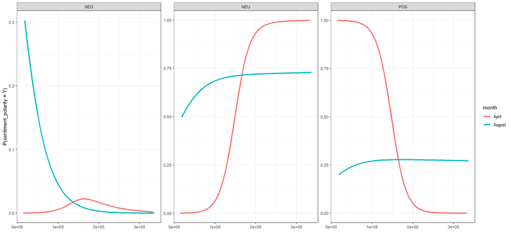

```r
## multinomial model ####
newdf_3_multinom <- data.frame(
    confirmed = seq(
        from = min(df_ana_2$confirmed),
        to = max(df_ana_2$confirmed), length.out = 100
    ),
    deaths = rep(mean(df_ana_2$deaths), 500),
    recovered = rep(mean(df_ana_2$recovered), 500),
    month = as.factor(rep(levels(df_ana_2$month), 500))
)
prob_sentiment <- predict(multi_mod_3,
    newdata = newdf_3_multinom,
    type = "probs", se = TRUE
)
predicted_probs_3 <- cbind(newdf_3_multinom, prob_sentiment)

# to long format
long_predicted_probs_3 <- gather(predicted_probs_3,
    key = "Sentiment_Polarity",
    value = "probability",
    -confirmed, -deaths, -recovered, -month,
    factor_key = TRUE
)
ggplot(
    data = long_predicted_probs_3,
    aes(x = confirmed, y = probability, color = month)
) +
    geom_line(size = 1.3) +
    xlab("") +
    ylab("P(sentiment_polarity = Y)") +
    theme_bw() +
    facet_wrap(~Sentiment_Polarity, scales = "free")
```